# Risk Factor Analysis

## Outcome Variable

**Outcome Variable:** y_rate_wtkg

## Predictor Variables

**Intervention Variable:** predfeed36

**Adjustment Set:**

- arm
- sex
- month
- brthmon
- W_mage
- meducyrs
- feducyrs
- hhwealth_quart
- hfoodsec
- W_mhtcm
- W_mwtkg
- W_mbmi
- vagbrth
- W_birthwt
- W_birthlen
- single
- W_nrooms
- impfloor
- impsan
- safeh20
- delta_W_mage
- delta_meducyrs
- delta_feducyrs
- delta_hhwealth_quart
- delta_hfoodsec
- delta_W_mhtcm
- delta_W_mwtkg
- delta_W_mbmi
- delta_vagbrth
- delta_W_birthwt
- delta_W_birthlen
- delta_single
- delta_W_nrooms
- delta_impfloor
- delta_impsan
- delta_safeh20

## Stratifying Variables

The analysis was stratified on these variable(s):

- agecat
- studyid
- country

## Data Summary

| agecat | studyid | country | predfeed36 | n_cell | n |
| --- | --- | --- | --- | --- | --- |
| 0-3 months | EE | PAKISTAN | 1 | 3 | 7 |
| 0-3 months | EE | PAKISTAN | 0 | 4 | 7 |
| 0-3 months | GMS-Nepal | NEPAL | 1 | 373 | 466 |
| 0-3 months | GMS-Nepal | NEPAL | 0 | 93 | 466 |
| 0-3 months | JiVitA-3 | BANGLADESH | 1 | 7730 | 9919 |
| 0-3 months | JiVitA-3 | BANGLADESH | 0 | 2189 | 9919 |
| 0-3 months | JiVitA-4 | BANGLADESH | 1 | 1399 | 1675 |
| 0-3 months | JiVitA-4 | BANGLADESH | 0 | 276 | 1675 |
| 0-3 months | MAL-ED | BANGLADESH | 1 | 83 | 245 |
| 0-3 months | MAL-ED | BANGLADESH | 0 | 162 | 245 |
| 0-3 months | MAL-ED | BRAZIL | 1 | 27 | 217 |
| 0-3 months | MAL-ED | BRAZIL | 0 | 190 | 217 |
| 0-3 months | MAL-ED | INDIA | 1 | 18 | 235 |
| 0-3 months | MAL-ED | INDIA | 0 | 217 | 235 |
| 0-3 months | MAL-ED | NEPAL | 1 | 9 | 230 |
| 0-3 months | MAL-ED | NEPAL | 0 | 221 | 230 |
| 0-3 months | MAL-ED | PERU | 1 | 77 | 280 |
| 0-3 months | MAL-ED | PERU | 0 | 203 | 280 |
| 0-3 months | MAL-ED | SOUTH AFRICA | 1 | 5 | 268 |
| 0-3 months | MAL-ED | SOUTH AFRICA | 0 | 263 | 268 |
| 0-3 months | MAL-ED | TANZANIA, UNITED REPUBLIC OF | 1 | 4 | 232 |
| 0-3 months | MAL-ED | TANZANIA, UNITED REPUBLIC OF | 0 | 228 | 232 |
| 3-6 months | EE | PAKISTAN | 1 | 3 | 7 |
| 3-6 months | EE | PAKISTAN | 0 | 4 | 7 |
| 3-6 months | GMS-Nepal | NEPAL | 1 | 367 | 460 |
| 3-6 months | GMS-Nepal | NEPAL | 0 | 93 | 460 |
| 3-6 months | JiVitA-3 | BANGLADESH | 1 | 5133 | 6658 |
| 3-6 months | JiVitA-3 | BANGLADESH | 0 | 1525 | 6658 |
| 3-6 months | JiVitA-4 | BANGLADESH | 1 | 1485 | 1755 |
| 3-6 months | JiVitA-4 | BANGLADESH | 0 | 270 | 1755 |

[output cut: 150 more lines]

The following strata were considered:

- agecat: 0-3 months, studyid: EE, country: PAKISTAN
- agecat: 0-3 months, studyid: GMS-Nepal, country: NEPAL
- agecat: 0-3 months, studyid: JiVitA-3, country: BANGLADESH
- agecat: 0-3 months, studyid: JiVitA-4, country: BANGLADESH
- agecat: 0-3 months, studyid: MAL-ED, country: BANGLADESH
- agecat: 0-3 months, studyid: MAL-ED, country: BRAZIL
- agecat: 0-3 months, studyid: MAL-ED, country: INDIA
- agecat: 0-3 months, studyid: MAL-ED, country: NEPAL
- agecat: 0-3 months, studyid: MAL-ED, country: PERU
- agecat: 0-3 months, studyid: MAL-ED, country: SOUTH AFRICA
- agecat: 0-3 months, studyid: MAL-ED, country: TANZANIA, UNITED REPUBLIC OF
- agecat: 12-15 months, studyid: EE, country: PAKISTAN
- agecat: 12-15 months, studyid: GMS-Nepal, country: NEPAL
- agecat: 12-15 months, studyid: JiVitA-4, country: BANGLADESH
- agecat: 12-15 months, studyid: LCNI-5, country: MALAWI
- agecat: 12-15 months, studyid: MAL-ED, country: BANGLADESH
- agecat: 12-15 months, studyid: MAL-ED, country: BRAZIL
- agecat: 12-15 months, studyid: MAL-ED, country: INDIA
- agecat: 12-15 months, studyid: MAL-ED, country: NEPAL
- agecat: 12-15 months, studyid: MAL-ED, country: PERU
- agecat: 12-15 months, studyid: MAL-ED, country: SOUTH AFRICA
- agecat: 12-15 months, studyid: MAL-ED, country: TANZANIA, UNITED REPUBLIC OF
- agecat: 12-15 months, studyid: SAS-FoodSuppl, country: INDIA
- agecat: 15-18 months, studyid: EE, country: PAKISTAN
- agecat: 15-18 months, studyid: GMS-Nepal, country: NEPAL
- agecat: 15-18 months, studyid: JiVitA-4, country: BANGLADESH
- agecat: 15-18 months, studyid: LCNI-5, country: MALAWI
- agecat: 15-18 months, studyid: MAL-ED, country: BANGLADESH
- agecat: 15-18 months, studyid: MAL-ED, country: BRAZIL
- agecat: 15-18 months, studyid: MAL-ED, country: INDIA
- agecat: 15-18 months, studyid: MAL-ED, country: NEPAL
- agecat: 15-18 months, studyid: MAL-ED, country: PERU
- agecat: 15-18 months, studyid: MAL-ED, country: SOUTH AFRICA
- agecat: 15-18 months, studyid: MAL-ED, country: TANZANIA, UNITED REPUBLIC OF
- agecat: 15-18 months, studyid: SAS-FoodSuppl, country: INDIA
- agecat: 18-21 months, studyid: EE, country: PAKISTAN
- agecat: 18-21 months, studyid: GMS-Nepal, country: NEPAL
- agecat: 18-21 months, studyid: LCNI-5, country: MALAWI
- agecat: 18-21 months, studyid: MAL-ED, country: BANGLADESH
- agecat: 18-21 months, studyid: MAL-ED, country: BRAZIL
- agecat: 18-21 months, studyid: MAL-ED, country: INDIA
- agecat: 18-21 months, studyid: MAL-ED, country: NEPAL
- agecat: 18-21 months, studyid: MAL-ED, country: PERU
- agecat: 18-21 months, studyid: MAL-ED, country: SOUTH AFRICA
- agecat: 18-21 months, studyid: MAL-ED, country: TANZANIA, UNITED REPUBLIC OF
- agecat: 21-24 months, studyid: EE, country: PAKISTAN
- agecat: 21-24 months, studyid: GMS-Nepal, country: NEPAL
- agecat: 21-24 months, studyid: LCNI-5, country: MALAWI
- agecat: 21-24 months, studyid: MAL-ED, country: BANGLADESH
- agecat: 21-24 months, studyid: MAL-ED, country: BRAZIL
- agecat: 21-24 months, studyid: MAL-ED, country: INDIA
- agecat: 21-24 months, studyid: MAL-ED, country: NEPAL
- agecat: 21-24 months, studyid: MAL-ED, country: PERU
- agecat: 21-24 months, studyid: MAL-ED, country: SOUTH AFRICA
- agecat: 21-24 months, studyid: MAL-ED, country: TANZANIA, UNITED REPUBLIC OF
- agecat: 3-6 months, studyid: EE, country: PAKISTAN
- agecat: 3-6 months, studyid: GMS-Nepal, country: NEPAL
- agecat: 3-6 months, studyid: JiVitA-3, country: BANGLADESH
- agecat: 3-6 months, studyid: JiVitA-4, country: BANGLADESH
- agecat: 3-6 months, studyid: MAL-ED, country: BANGLADESH
- agecat: 3-6 months, studyid: MAL-ED, country: BRAZIL
- agecat: 3-6 months, studyid: MAL-ED, country: INDIA
- agecat: 3-6 months, studyid: MAL-ED, country: NEPAL
- agecat: 3-6 months, studyid: MAL-ED, country: PERU
- agecat: 3-6 months, studyid: MAL-ED, country: SOUTH AFRICA
- agecat: 3-6 months, studyid: MAL-ED, country: TANZANIA, UNITED REPUBLIC OF
- agecat: 6-9 months, studyid: EE, country: PAKISTAN
- agecat: 6-9 months, studyid: GMS-Nepal, country: NEPAL
- agecat: 6-9 months, studyid: JiVitA-4, country: BANGLADESH
- agecat: 6-9 months, studyid: LCNI-5, country: MALAWI
- agecat: 6-9 months, studyid: MAL-ED, country: BANGLADESH
- agecat: 6-9 months, studyid: MAL-ED, country: BRAZIL
- agecat: 6-9 months, studyid: MAL-ED, country: INDIA
- agecat: 6-9 months, studyid: MAL-ED, country: NEPAL
- agecat: 6-9 months, studyid: MAL-ED, country: PERU
- agecat: 6-9 months, studyid: MAL-ED, country: SOUTH AFRICA
- agecat: 6-9 months, studyid: MAL-ED, country: TANZANIA, UNITED REPUBLIC OF
- agecat: 6-9 months, studyid: SAS-FoodSuppl, country: INDIA
- agecat: 9-12 months, studyid: EE, country: PAKISTAN
- agecat: 9-12 months, studyid: GMS-Nepal, country: NEPAL
- agecat: 9-12 months, studyid: JiVitA-4, country: BANGLADESH
- agecat: 9-12 months, studyid: LCNI-5, country: MALAWI
- agecat: 9-12 months, studyid: MAL-ED, country: BANGLADESH
- agecat: 9-12 months, studyid: MAL-ED, country: BRAZIL
- agecat: 9-12 months, studyid: MAL-ED, country: INDIA
- agecat: 9-12 months, studyid: MAL-ED, country: NEPAL
- agecat: 9-12 months, studyid: MAL-ED, country: PERU
- agecat: 9-12 months, studyid: MAL-ED, country: SOUTH AFRICA
- agecat: 9-12 months, studyid: MAL-ED, country: TANZANIA, UNITED REPUBLIC OF
- agecat: 9-12 months, studyid: SAS-FoodSuppl, country: INDIA

### Dropped Strata

Some strata were dropped due to rare outcomes:

- agecat: 0-3 months, studyid: EE, country: PAKISTAN
- agecat: 0-3 months, studyid: MAL-ED, country: TANZANIA, UNITED REPUBLIC OF
- agecat: 3-6 months, studyid: EE, country: PAKISTAN
- agecat: 3-6 months, studyid: MAL-ED, country: SOUTH AFRICA
- agecat: 6-9 months, studyid: EE, country: PAKISTAN
- agecat: 6-9 months, studyid: MAL-ED, country: SOUTH AFRICA
- agecat: 6-9 months, studyid: SAS-FoodSuppl, country: INDIA
- agecat: 9-12 months, studyid: EE, country: PAKISTAN
- agecat: 9-12 months, studyid: MAL-ED, country: SOUTH AFRICA
- agecat: 9-12 months, studyid: MAL-ED, country: TANZANIA, UNITED REPUBLIC OF
- agecat: 9-12 months, studyid: SAS-FoodSuppl, country: INDIA
- agecat: 12-15 months, studyid: EE, country: PAKISTAN
- agecat: 12-15 months, studyid: LCNI-5, country: MALAWI
- agecat: 12-15 months, studyid: MAL-ED, country: SOUTH AFRICA
- agecat: 12-15 months, studyid: MAL-ED, country: TANZANIA, UNITED REPUBLIC OF
- agecat: 12-15 months, studyid: SAS-FoodSuppl, country: INDIA
- agecat: 15-18 months, studyid: EE, country: PAKISTAN
- agecat: 15-18 months, studyid: LCNI-5, country: MALAWI
- agecat: 15-18 months, studyid: MAL-ED, country: SOUTH AFRICA
- agecat: 15-18 months, studyid: MAL-ED, country: TANZANIA, UNITED REPUBLIC OF
- agecat: 15-18 months, studyid: SAS-FoodSuppl, country: INDIA
- agecat: 18-21 months, studyid: EE, country: PAKISTAN
- agecat: 18-21 months, studyid: MAL-ED, country: SOUTH AFRICA
- agecat: 18-21 months, studyid: MAL-ED, country: TANZANIA, UNITED REPUBLIC OF
- agecat: 21-24 months, studyid: EE, country: PAKISTAN
- agecat: 21-24 months, studyid: MAL-ED, country: SOUTH AFRICA
- agecat: 21-24 months, studyid: MAL-ED, country: TANZANIA, UNITED REPUBLIC OF

## Methods Detail

We’re interested in the causal parameters $E[Y_a]$ for all values of $a \in \mathcal{A}$. These parameters represent the mean outcome if, possibly contrary to fact, we intervened to set all units to have $A=a$. Under the randomization and positivity assumptions, these are identified by the statistical parameters $\psi_a=E_W[E_{Y|A,W}(Y|A=a,W)]$. In addition, we’re interested in the mean of $Y$, $E[Y]$ under no intervention (the observed mean). We will estimate these parameters by using SuperLearner to fit the relevant likelihood factors – $E_{Y|A,W}(Y|A=a,W)$ and $p(A=a|W)$, and then updating our likelihood fit using a joint TMLE.

For unadjusted analyses ($W=\{\}$), initial likelihoods were estimated using Lrnr_glm to estimate the simple $E(Y|A)$ and Lrnr_mean to estimate $p(A)$. For adjusted analyses, a small library containing Lrnr_glmnet, Lrnr_xgboost, and Lrnr_mean was used.

Having estimated these parameters, we will then use the delta method to estimate relative risks and attributable risks relative to a prespecified baseline level of $A$.

# Results Detail

## Results Plots

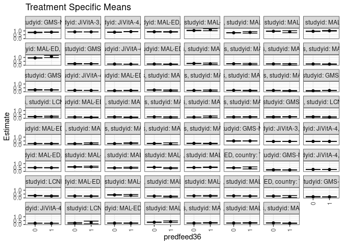

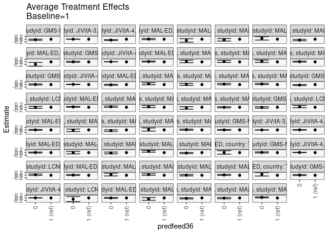

[figure not shown]

## Results Table

### Parameter: TSM

| agecat | studyid | country | intervention_level | baseline_level | estimate | ci_lower | ci_upper |
| --- | --- | --- | --- | --- | --- | --- | --- |
| 0-3 months | GMS-Nepal | NEPAL | 1 | NA | 0.8377489 | 0.8177413 | 0.8577564 |
| 0-3 months | GMS-Nepal | NEPAL | 0 | NA | 0.7978391 | 0.7586516 | 0.8370266 |
| 0-3 months | JiVitA-3 | BANGLADESH | 1 | NA | 0.8691120 | 0.8646147 | 0.8736092 |
| 0-3 months | JiVitA-3 | BANGLADESH | 0 | NA | 0.8704020 | 0.8607340 | 0.8800699 |
| 0-3 months | JiVitA-4 | BANGLADESH | 1 | NA | 0.9002988 | 0.8890894 | 0.9115081 |
| 0-3 months | JiVitA-4 | BANGLADESH | 0 | NA | 0.8336174 | 0.8063766 | 0.8608581 |
| 0-3 months | MAL-ED | BANGLADESH | 1 | NA | 0.8757570 | 0.8391723 | 0.9123418 |
| 0-3 months | MAL-ED | BANGLADESH | 0 | NA | 0.8845095 | 0.8546845 | 0.9143346 |
| 0-3 months | MAL-ED | BRAZIL | 1 | NA | 1.1506897 | 1.0178837 | 1.2834957 |
| 0-3 months | MAL-ED | BRAZIL | 0 | NA | 1.0550784 | 1.0196468 | 1.0905100 |
| 0-3 months | MAL-ED | INDIA | 1 | NA | 0.8034047 | 0.7058563 | 0.9009530 |
| 0-3 months | MAL-ED | INDIA | 0 | NA | 0.7558263 | 0.7326596 | 0.7789931 |
| 0-3 months | MAL-ED | NEPAL | 1 | NA | 0.8917231 | 0.7591937 | 1.0242525 |
| 0-3 months | MAL-ED | NEPAL | 0 | NA | 0.9592919 | 0.9317769 | 0.9868068 |
| 0-3 months | MAL-ED | PERU | 1 | NA | 1.0128687 | 0.9660978 | 1.0596397 |
| 0-3 months | MAL-ED | PERU | 0 | NA | 0.9506000 | 0.9211678 | 0.9800322 |
| 0-3 months | MAL-ED | SOUTH AFRICA | 1 | NA | 1.1240287 | 0.9802729 | 1.2677845 |
| 0-3 months | MAL-ED | SOUTH AFRICA | 0 | NA | 0.9375440 | 0.9105230 | 0.9645650 |
| 3-6 months | GMS-Nepal | NEPAL | 1 | NA | 0.4960921 | 0.4799501 | 0.5122340 |
| 3-6 months | GMS-Nepal | NEPAL | 0 | NA | 0.4969200 | 0.4680122 | 0.5258278 |
| 3-6 months | JiVitA-3 | BANGLADESH | 1 | NA | 0.4385398 | 0.4339614 | 0.4431181 |
| 3-6 months | JiVitA-3 | BANGLADESH | 0 | NA | 0.4345737 | 0.4212883 | 0.4478592 |
| 3-6 months | JiVitA-4 | BANGLADESH | 1 | NA | 0.4377835 | 0.4276328 | 0.4479342 |
| 3-6 months | JiVitA-4 | BANGLADESH | 0 | NA | 0.4429608 | 0.4211632 | 0.4647585 |
| 3-6 months | MAL-ED | BANGLADESH | 1 | NA | 0.4677963 | 0.4411925 | 0.4944001 |
| 3-6 months | MAL-ED | BANGLADESH | 0 | NA | 0.4771405 | 0.4557615 | 0.4985195 |
| 3-6 months | MAL-ED | BRAZIL | 1 | NA | 0.5792061 | 0.4905231 | 0.6678891 |
| 3-6 months | MAL-ED | BRAZIL | 0 | NA | 0.5772213 | 0.5435649 | 0.6108777 |
| 3-6 months | MAL-ED | INDIA | 1 | NA | 0.4708617 | 0.4026547 | 0.5390688 |
| 3-6 months | MAL-ED | INDIA | 0 | NA | 0.4450933 | 0.4270174 | 0.4631692 |

[output cut: 96 more lines]

### Parameter: E(Y)

| agecat | studyid | country | intervention_level | baseline_level | estimate | ci_lower | ci_upper |
| --- | --- | --- | --- | --- | --- | --- | --- |
| 0-3 months | GMS-Nepal | NEPAL | NA | NA | 0.8290682 | 0.8112267 | 0.8469097 |
| 0-3 months | JiVitA-3 | BANGLADESH | NA | NA | 0.8693660 | 0.8652018 | 0.8735301 |
| 0-3 months | JiVitA-4 | BANGLADESH | NA | NA | 0.8892195 | 0.8786542 | 0.8997847 |
| 0-3 months | MAL-ED | BANGLADESH | NA | NA | 0.8793764 | 0.8562449 | 0.9025078 |
| 0-3 months | MAL-ED | BRAZIL | NA | NA | 1.0655134 | 1.0311555 | 1.0998713 |
| 0-3 months | MAL-ED | INDIA | NA | NA | 0.7588477 | 0.7364127 | 0.7812826 |
| 0-3 months | MAL-ED | NEPAL | NA | NA | 0.9566479 | 0.9296524 | 0.9836434 |
| 0-3 months | MAL-ED | PERU | NA | NA | 0.9709635 | 0.9457785 | 0.9961485 |
| 0-3 months | MAL-ED | SOUTH AFRICA | NA | NA | 0.9410232 | 0.9142620 | 0.9677844 |
| 3-6 months | GMS-Nepal | NEPAL | NA | NA | 0.4969685 | 0.4829796 | 0.5109574 |
| 3-6 months | JiVitA-3 | BANGLADESH | NA | NA | 0.4376750 | 0.4329472 | 0.4424029 |
| 3-6 months | JiVitA-4 | BANGLADESH | NA | NA | 0.4386833 | 0.4295081 | 0.4478585 |
| 3-6 months | MAL-ED | BANGLADESH | NA | NA | 0.4740560 | 0.4573508 | 0.4907612 |
| 3-6 months | MAL-ED | BRAZIL | NA | NA | 0.5781976 | 0.5469697 | 0.6094254 |
| 3-6 months | MAL-ED | INDIA | NA | NA | 0.4437256 | 0.4262017 | 0.4612496 |
| 3-6 months | MAL-ED | NEPAL | NA | NA | 0.5221660 | 0.5019198 | 0.5424121 |
| 3-6 months | MAL-ED | PERU | NA | NA | 0.4982335 | 0.4792789 | 0.5171881 |
| 3-6 months | MAL-ED | TANZANIA, UNITED REPUBLIC OF | NA | NA | 0.4578547 | 0.4335136 | 0.4821959 |
| 6-9 months | GMS-Nepal | NEPAL | NA | NA | 0.1871486 | 0.1748771 | 0.1994201 |
| 6-9 months | JiVitA-4 | BANGLADESH | NA | NA | 0.2387387 | 0.2332737 | 0.2442038 |
| 6-9 months | LCNI-5 | MALAWI | NA | NA | 0.2829175 | 0.2578313 | 0.3080037 |
| 6-9 months | MAL-ED | BANGLADESH | NA | NA | 0.2428552 | 0.2283339 | 0.2573765 |
| 6-9 months | MAL-ED | BRAZIL | NA | NA | 0.3831499 | 0.3570859 | 0.4092138 |
| 6-9 months | MAL-ED | INDIA | NA | NA | 0.2306231 | 0.2156296 | 0.2456166 |
| 6-9 months | MAL-ED | NEPAL | NA | NA | 0.2699886 | 0.2554702 | 0.2845071 |
| 6-9 months | MAL-ED | PERU | NA | NA | 0.2613933 | 0.2459015 | 0.2768851 |
| 6-9 months | MAL-ED | TANZANIA, UNITED REPUBLIC OF | NA | NA | 0.2385095 | 0.2143193 | 0.2626996 |
| 9-12 months | GMS-Nepal | NEPAL | NA | NA | 0.1395865 | 0.1265823 | 0.1525906 |
| 9-12 months | JiVitA-4 | BANGLADESH | NA | NA | 0.1533597 | 0.1488837 | 0.1578358 |
| 9-12 months | LCNI-5 | MALAWI | NA | NA | 0.1849664 | 0.1167599 | 0.2531730 |
| 9-12 months | MAL-ED | BANGLADESH | NA | NA | 0.1730346 | 0.1593686 | 0.1867006 |
| 9-12 months | MAL-ED | BRAZIL | NA | NA | 0.2845923 | 0.2527896 | 0.3163950 |
| 9-12 months | MAL-ED | INDIA | NA | NA | 0.1787492 | 0.1645237 | 0.1929747 |
| 9-12 months | MAL-ED | NEPAL | NA | NA | 0.1857420 | 0.1712835 | 0.2002004 |
| 9-12 months | MAL-ED | PERU | NA | NA | 0.1874806 | 0.1721694 | 0.2027919 |
| 12-15 months | GMS-Nepal | NEPAL | NA | NA | 0.1746639 | 0.1610783 | 0.1882495 |
| 12-15 months | JiVitA-4 | BANGLADESH | NA | NA | 0.1308582 | 0.1262352 | 0.1354811 |
| 12-15 months | MAL-ED | BANGLADESH | NA | NA | 0.1353586 | 0.1195861 | 0.1511312 |
| 12-15 months | MAL-ED | BRAZIL | NA | NA | 0.2101946 | 0.1853699 | 0.2350192 |
| 12-15 months | MAL-ED | INDIA | NA | NA | 0.1739653 | 0.1578765 | 0.1900541 |
| 12-15 months | MAL-ED | NEPAL | NA | NA | 0.1525937 | 0.1359182 | 0.1692692 |
| 12-15 months | MAL-ED | PERU | NA | NA | 0.1417390 | 0.1250455 | 0.1584325 |
| 15-18 months | GMS-Nepal | NEPAL | NA | NA | 0.2291397 | 0.2134657 | 0.2448138 |
| 15-18 months | JiVitA-4 | BANGLADESH | NA | NA | 0.1598556 | 0.1545499 | 0.1651613 |
| 15-18 months | MAL-ED | BANGLADESH | NA | NA | 0.1427882 | 0.1271818 | 0.1583946 |
| 15-18 months | MAL-ED | BRAZIL | NA | NA | 0.2034195 | 0.1767881 | 0.2300509 |
| 15-18 months | MAL-ED | INDIA | NA | NA | 0.1642299 | 0.1493519 | 0.1791079 |
| 15-18 months | MAL-ED | NEPAL | NA | NA | 0.1731820 | 0.1573733 | 0.1889907 |
| 15-18 months | MAL-ED | PERU | NA | NA | 0.1461889 | 0.1273267 | 0.1650511 |
| 18-21 months | GMS-Nepal | NEPAL | NA | NA | 0.1428759 | 0.1266216 | 0.1591302 |
| 18-21 months | LCNI-5 | MALAWI | NA | NA | 0.2016785 | 0.1726437 | 0.2307133 |
| 18-21 months | MAL-ED | BANGLADESH | NA | NA | 0.1427146 | 0.1257942 | 0.1596351 |
| 18-21 months | MAL-ED | BRAZIL | NA | NA | 0.1606491 | 0.1365241 | 0.1847741 |
| 18-21 months | MAL-ED | INDIA | NA | NA | 0.1701596 | 0.1556514 | 0.1846677 |
| 18-21 months | MAL-ED | NEPAL | NA | NA | 0.1474939 | 0.1297619 | 0.1652260 |
| 18-21 months | MAL-ED | PERU | NA | NA | 0.1615652 | 0.1425950 | 0.1805355 |
| 21-24 months | GMS-Nepal | NEPAL | NA | NA | 0.1784694 | 0.1533807 | 0.2035582 |
| 21-24 months | LCNI-5 | MALAWI | NA | NA | 0.1779746 | 0.1356818 | 0.2202674 |
| 21-24 months | MAL-ED | BANGLADESH | NA | NA | 0.1521155 | 0.1369898 | 0.1672413 |
| 21-24 months | MAL-ED | BRAZIL | NA | NA | 0.1434900 | 0.1201394 | 0.1668407 |
| 21-24 months | MAL-ED | INDIA | NA | NA | 0.1565193 | 0.1433011 | 0.1697376 |
| 21-24 months | MAL-ED | NEPAL | NA | NA | 0.1696243 | 0.1496620 | 0.1895867 |
| 21-24 months | MAL-ED | PERU | NA | NA | 0.1814671 | 0.1617319 | 0.2012023 |

### Parameter: ATE

| agecat | studyid | country | intervention_level | baseline_level | estimate | ci_lower | ci_upper |
| --- | --- | --- | --- | --- | --- | --- | --- |
| 0-3 months | GMS-Nepal | NEPAL | 1 | 1 | 0.0000000 | 0.0000000 | 0.0000000 |
| 0-3 months | GMS-Nepal | NEPAL | 0 | 1 | -0.0399098 | -0.0839160 | 0.0040965 |
| 0-3 months | JiVitA-3 | BANGLADESH | 1 | 1 | 0.0000000 | 0.0000000 | 0.0000000 |
| 0-3 months | JiVitA-3 | BANGLADESH | 0 | 1 | 0.0012900 | -0.0092345 | 0.0118146 |
| 0-3 months | JiVitA-4 | BANGLADESH | 1 | 1 | 0.0000000 | 0.0000000 | 0.0000000 |
| 0-3 months | JiVitA-4 | BANGLADESH | 0 | 1 | -0.0666814 | -0.0961456 | -0.0372172 |
| 0-3 months | MAL-ED | BANGLADESH | 1 | 1 | 0.0000000 | 0.0000000 | 0.0000000 |
| 0-3 months | MAL-ED | BANGLADESH | 0 | 1 | 0.0087525 | -0.0386022 | 0.0561072 |
| 0-3 months | MAL-ED | BRAZIL | 1 | 1 | 0.0000000 | 0.0000000 | 0.0000000 |
| 0-3 months | MAL-ED | BRAZIL | 0 | 1 | -0.0956113 | -0.2328923 | 0.0416697 |
| 0-3 months | MAL-ED | INDIA | 1 | 1 | 0.0000000 | 0.0000000 | 0.0000000 |
| 0-3 months | MAL-ED | INDIA | 0 | 1 | -0.0475783 | -0.1479116 | 0.0527550 |
| 0-3 months | MAL-ED | NEPAL | 1 | 1 | 0.0000000 | 0.0000000 | 0.0000000 |
| 0-3 months | MAL-ED | NEPAL | 0 | 1 | 0.0675688 | -0.0677867 | 0.2029243 |
| 0-3 months | MAL-ED | PERU | 1 | 1 | 0.0000000 | 0.0000000 | 0.0000000 |
| 0-3 months | MAL-ED | PERU | 0 | 1 | -0.0622688 | -0.1176159 | -0.0069216 |
| 0-3 months | MAL-ED | SOUTH AFRICA | 1 | 1 | 0.0000000 | 0.0000000 | 0.0000000 |
| 0-3 months | MAL-ED | SOUTH AFRICA | 0 | 1 | -0.1864847 | -0.3327579 | -0.0402114 |
| 3-6 months | GMS-Nepal | NEPAL | 1 | 1 | 0.0000000 | 0.0000000 | 0.0000000 |
| 3-6 months | GMS-Nepal | NEPAL | 0 | 1 | 0.0008280 | -0.0323508 | 0.0340067 |
| 3-6 months | JiVitA-3 | BANGLADESH | 1 | 1 | 0.0000000 | 0.0000000 | 0.0000000 |
| 3-6 months | JiVitA-3 | BANGLADESH | 0 | 1 | -0.0039660 | -0.0178642 | 0.0099321 |
| 3-6 months | JiVitA-4 | BANGLADESH | 1 | 1 | 0.0000000 | 0.0000000 | 0.0000000 |
| 3-6 months | JiVitA-4 | BANGLADESH | 0 | 1 | 0.0051773 | -0.0188216 | 0.0291762 |
| 3-6 months | MAL-ED | BANGLADESH | 1 | 1 | 0.0000000 | 0.0000000 | 0.0000000 |
| 3-6 months | MAL-ED | BANGLADESH | 0 | 1 | 0.0093442 | -0.0249261 | 0.0436145 |
| 3-6 months | MAL-ED | BRAZIL | 1 | 1 | 0.0000000 | 0.0000000 | 0.0000000 |
| 3-6 months | MAL-ED | BRAZIL | 0 | 1 | -0.0019848 | -0.0964636 | 0.0924940 |
| 3-6 months | MAL-ED | INDIA | 1 | 1 | 0.0000000 | 0.0000000 | 0.0000000 |
| 3-6 months | MAL-ED | INDIA | 0 | 1 | -0.0257684 | -0.0962659 | 0.0447290 |

[output cut: 96 more lines]

### Parameter: PAR

| agecat | studyid | country | intervention_level | baseline_level | estimate | ci_lower | ci_upper |
| --- | --- | --- | --- | --- | --- | --- | --- |
| 0-3 months | GMS-Nepal | NEPAL | 1 | NA | -0.0086807 | -0.0175043 | 0.0001429 |
| 0-3 months | JiVitA-3 | BANGLADESH | 1 | NA | 0.0002540 | -0.0020635 | 0.0025715 |
| 0-3 months | JiVitA-4 | BANGLADESH | 1 | NA | -0.0110793 | -0.0163709 | -0.0057877 |
| 0-3 months | MAL-ED | BANGLADESH | 1 | NA | 0.0036193 | -0.0276774 | 0.0349161 |
| 0-3 months | MAL-ED | BRAZIL | 1 | NA | -0.0851763 | -0.2086669 | 0.0383143 |
| 0-3 months | MAL-ED | INDIA | 1 | NA | -0.0445570 | -0.1379660 | 0.0488520 |
| 0-3 months | MAL-ED | NEPAL | 1 | NA | 0.0649248 | -0.0651452 | 0.1949949 |
| 0-3 months | MAL-ED | PERU | 1 | NA | -0.0419052 | -0.0823333 | -0.0014771 |
| 0-3 months | MAL-ED | SOUTH AFRICA | 1 | NA | -0.1830055 | -0.3256540 | -0.0403569 |
| 3-6 months | GMS-Nepal | NEPAL | 1 | NA | 0.0008764 | -0.0056947 | 0.0074475 |
| 3-6 months | JiVitA-3 | BANGLADESH | 1 | NA | -0.0008647 | -0.0040366 | 0.0023071 |
| 3-6 months | JiVitA-4 | BANGLADESH | 1 | NA | 0.0008998 | -0.0027062 | 0.0045057 |
| 3-6 months | MAL-ED | BANGLADESH | 1 | NA | 0.0062597 | -0.0167853 | 0.0293047 |
| 3-6 months | MAL-ED | BRAZIL | 1 | NA | -0.0010086 | -0.0848401 | 0.0828230 |
| 3-6 months | MAL-ED | INDIA | 1 | NA | -0.0271361 | -0.0923883 | 0.0381161 |
| 3-6 months | MAL-ED | NEPAL | 1 | NA | 0.0983821 | 0.0302985 | 0.1664657 |
| 3-6 months | MAL-ED | PERU | 1 | NA | -0.0266214 | -0.0596891 | 0.0064464 |
| 3-6 months | MAL-ED | TANZANIA, UNITED REPUBLIC OF | 1 | NA | 0.0104319 | -0.1235692 | 0.1444329 |
| 6-9 months | GMS-Nepal | NEPAL | 1 | NA | 0.0051337 | -0.0027404 | 0.0130078 |
| 6-9 months | JiVitA-4 | BANGLADESH | 1 | NA | 0.0023934 | -0.0001684 | 0.0049552 |
| 6-9 months | LCNI-5 | MALAWI | 1 | NA | 0.0379272 | -0.0060115 | 0.0818659 |
| 6-9 months | MAL-ED | BANGLADESH | 1 | NA | 0.0118781 | -0.0113193 | 0.0350756 |
| 6-9 months | MAL-ED | BRAZIL | 1 | NA | 0.0517043 | -0.0416540 | 0.1450626 |
| 6-9 months | MAL-ED | INDIA | 1 | NA | 0.0517286 | -0.0084659 | 0.1119230 |
| 6-9 months | MAL-ED | NEPAL | 1 | NA | 0.0071925 | -0.0429613 | 0.0573464 |
| 6-9 months | MAL-ED | PERU | 1 | NA | 0.0215472 | -0.0028487 | 0.0459431 |
| 6-9 months | MAL-ED | TANZANIA, UNITED REPUBLIC OF | 1 | NA | 0.0733124 | -0.0565170 | 0.2031417 |
| 9-12 months | GMS-Nepal | NEPAL | 1 | NA | 0.0034448 | -0.0028370 | 0.0097266 |
| 9-12 months | JiVitA-4 | BANGLADESH | 1 | NA | 0.0023181 | 0.0000457 | 0.0045905 |
| 9-12 months | LCNI-5 | MALAWI | 1 | NA | -0.0730564 | -0.2156697 | 0.0695568 |
| 9-12 months | MAL-ED | BANGLADESH | 1 | NA | 0.0006375 | -0.0201282 | 0.0214032 |
| 9-12 months | MAL-ED | BRAZIL | 1 | NA | -0.0743496 | -0.1682585 | 0.0195593 |
| 9-12 months | MAL-ED | INDIA | 1 | NA | -0.0320427 | -0.0749944 | 0.0109089 |
| 9-12 months | MAL-ED | NEPAL | 1 | NA | -0.0149358 | -0.0599333 | 0.0300617 |
| 9-12 months | MAL-ED | PERU | 1 | NA | 0.0307003 | 0.0060527 | 0.0553480 |
| 12-15 months | GMS-Nepal | NEPAL | 1 | NA | 0.0015099 | -0.0052997 | 0.0083195 |
| 12-15 months | JiVitA-4 | BANGLADESH | 1 | NA | 0.0027001 | 0.0003137 | 0.0050865 |
| 12-15 months | MAL-ED | BANGLADESH | 1 | NA | 0.0165078 | -0.0062232 | 0.0392388 |
| 12-15 months | MAL-ED | BRAZIL | 1 | NA | 0.0306614 | -0.0572750 | 0.1185977 |
| 12-15 months | MAL-ED | INDIA | 1 | NA | 0.0324902 | -0.0455919 | 0.1105722 |
| 12-15 months | MAL-ED | NEPAL | 1 | NA | 0.0467522 | -0.0427309 | 0.1362354 |
| 12-15 months | MAL-ED | PERU | 1 | NA | 0.0132257 | -0.0138637 | 0.0403150 |
| 15-18 months | GMS-Nepal | NEPAL | 1 | NA | 0.0011126 | -0.0068095 | 0.0090346 |
| 15-18 months | JiVitA-4 | BANGLADESH | 1 | NA | 0.0030852 | -0.0000171 | 0.0061875 |
| 15-18 months | MAL-ED | BANGLADESH | 1 | NA | -0.0119117 | -0.0392620 | 0.0154386 |
| 15-18 months | MAL-ED | BRAZIL | 1 | NA | 0.0525620 | -0.0164862 | 0.1216102 |
| 15-18 months | MAL-ED | INDIA | 1 | NA | 0.0153713 | -0.0582016 | 0.0889442 |
| 15-18 months | MAL-ED | NEPAL | 1 | NA | 0.0323446 | -0.0163637 | 0.0810528 |
| 15-18 months | MAL-ED | PERU | 1 | NA | 0.0331961 | 0.0008576 | 0.0655346 |
| 18-21 months | GMS-Nepal | NEPAL | 1 | NA | -0.0067304 | -0.0142493 | 0.0007884 |
| 18-21 months | LCNI-5 | MALAWI | 1 | NA | -0.0029248 | -0.0700459 | 0.0641962 |
| 18-21 months | MAL-ED | BANGLADESH | 1 | NA | 0.0163665 | -0.0105091 | 0.0432420 |
| 18-21 months | MAL-ED | BRAZIL | 1 | NA | 0.0384988 | -0.0101666 | 0.0871642 |
| 18-21 months | MAL-ED | INDIA | 1 | NA | 0.0472953 | -0.0253511 | 0.1199417 |
| 18-21 months | MAL-ED | NEPAL | 1 | NA | -0.0500002 | -0.1458218 | 0.0458213 |
| 18-21 months | MAL-ED | PERU | 1 | NA | -0.0081990 | -0.0406337 | 0.0242356 |
| 21-24 months | GMS-Nepal | NEPAL | 1 | NA | -0.0032888 | -0.0131657 | 0.0065880 |
| 21-24 months | LCNI-5 | MALAWI | 1 | NA | 0.0415483 | -0.0329002 | 0.1159967 |
| 21-24 months | MAL-ED | BANGLADESH | 1 | NA | 0.0011453 | -0.0220217 | 0.0243123 |
| 21-24 months | MAL-ED | BRAZIL | 1 | NA | -0.0261950 | -0.1136380 | 0.0612479 |
| 21-24 months | MAL-ED | INDIA | 1 | NA | -0.0478079 | -0.1076711 | 0.0120553 |
| 21-24 months | MAL-ED | NEPAL | 1 | NA | 0.0327130 | -0.0847755 | 0.1502015 |
| 21-24 months | MAL-ED | PERU | 1 | NA | 0.0129136 | -0.0208288 | 0.0466560 |